# Tutorial: Intro to Multi-level Modeling (MLM) Analysis in R

Sierra Corbin, M.A.

# 1 Load in Required Packages

```r
pacman::p_load(car,Hmisc,ppcor,psych,MASS, mctest, fBasics, foreign, jtools, lmerTest, lme4, tidyverse, dplyr, ggplot2, data.table, cowplot, performance) #loading in necessary packages (tools) for data analyses
```

# 2 Data Criteria & Simulation

## 2.1 Let’s review what our data should do

Simulate a hypothetical dataset to examine *L<sub>mean</sub>* as predicted by a *movePhase fixed effect*, and *part_ID random intercepts and slopes effects*.

- **Dependent Variable**: *L<sub>mean</sub>*, or the average CRQA line length per trial for intrapersonal hand-torso coupling during horizontal pointer movement trials. *Mean line length* is a measure of the predictability/stability of the coordination, with higher values indicating longer average periods of hand-torso coupling.
- **Independent Variable** (fixed effect): *movePhase fixed effect*, or the participant’s instructed pointer movement phase; relative to the on-screen target being tracked per trial.
  1. Avoid/anti-phase
  2. Approach/in-phase
- *N<sub>participants</sub>* = 50
- Within-Subjects Repeated Measures: 6 trials per condition (12 trials per participant)
- *N<sub>total.trials</sub>* = 600

Therefore, the final model is expected to be:
$$Y_{ij} = (b_0 + u_{0j}) + (b_1 + u_{1j}) *
X_{ij} + residual_{error}$$

… or (more specifically:
$$Lmean =
(Intercept + randIntEff) + (Slope + randSlopeEff) * movePhase +
residual_{error}$$
… which corresponds to the following final lmer model: `Lmean ~ movePhase + (movePhase|part_ID)`.

## 2.2 A Few Key Terms

- *Hierarchical Analysis*: describes the relationships that exist within and between the levels of nested data within the model; such analyses acknowledge the interdependence of nested data, considering fixed and random effects at both the individual and group-levels of interpretation.
- *Fixed Effect*: observations/measurements at the group-level of analysis; these sample estimates reflect the differences between groups (i.e.: regression main effects and interaction terms) while disregarding the additional context provided in the hierarchy.
- *Random Effect*: allow the regression coefficients to vary across groups, giving the model additional predictive flexibility in the resulting intercepts and slopes.
  1. *Random Intercepts*: assume that the intercept values for the model vary significantly with respect to individual (or lower level) observations, rather than expecting all individual relations to converge to a single intercept value; employing random intercepts, then, takes some of the onus off the fixed effect to account for such individual differences.
  2. *Random Slopes*: allow the lower-level observations to vary in relational strength with respect to the association between the predictors and outcome variables; for some lower-level observations, the effect of the predictor will be stronger/weaker than for others.

Now that we have a conceptual basis for MLMs, let’s make some data!

## 2.3 Simulating the dataset:

### 2.3.1 First, let’s set some of the fixed effect paramerters

```r
Lmean_grandM <- 125 #chosen (grand) mean for the entire dataset
n_participant <- 50 #number of participants
eff.size_mP <- .707 #pearson's r for a chosen cohen's d of 2 (large eff. size)
tot_trials <- 600 #number of overall trials
```

### 2.3.2 Now we must partition the random effects and residual error variance

```r
residual_variance <- 1 - eff.size_mP^2 #variance left after including condition fixed effect
residual_sd <- sqrt(residual_variance) #SD of the residual variance after condition effect
```

### 2.3.3 Randomly generating the intercept and slope effects, partitioning variance (cont’d)

```r
set.seed(1) #setting seed insures reproducibility of intercept effect outputs
intvar_bypart <- .30 #arbitrarily chosen intercept variance value; this will help calculate the random intercept values that will be used to account for differences by participant.
intsd_bypart <- sqrt(intvar_bypart) #corresponding SD for random intercepts
per_part_int <- rnorm(n_participant, 0, intsd_bypart) #rnorm function used to simulate 50 random participant intercept adjustment values

residual_variance2 <- residual_variance-intvar_bypart #variance left to be claimed after allocation for random intercepts
residual_sd2 <- sqrt(residual_variance2) #SD of the residual variance after random intercepts effect

set.seed(2) #setting seed insures reproducibility of slope effect outputs
slope_eff <- sqrt(.15) #chosen value corresponding to SD for random slopes (.15 of .20 left variance); this will help calculate the random slope values that will be used to account for differences by participant.
per_part_slope <- rnorm(n_participant,0,slope_eff) #rnorm function used to simulate 50 random participant slope adjustment values
```

### 2.3.4 Building the data frame

```r
#bringing our participant-level data together:
partData <- data.frame(part_ID = as.factor(1:n_participant), #create 50 participant IDs
                       per_part_int, #adds random intercept adjustment for each
                       per_part_slope) #add random slope adjustment for each
```

### 2.3.5 Randomly generating the residual variance

```r
set.seed(3) #setting seed insures reproducibility of residual effect outputs
resid_eff <- residual_sd2 - slope_eff
resids <- rnorm(tot_trials, 0, resid_eff)
```

### 2.3.6 Bringing the final data frame together with resulting Lmean values

```r
participant_id = as.factor(rep(1:n_participant, each = 12)) #extending part_ID for all 600 trials

#bringing our trial-level data together:
trialData <- data.frame(part_ID = participant_id, #including all participant IDs for the 600 trials
                        trial = as_factor(1:12), #including the within-subjects trial count
                        movePhase = 1:2, #Movement condition for each trial: 1 = Avoid, 2 = Approach
                        Phase = as_factor(c("Avoid", "Approach")), #categorical copy of movePhase for labeling/visualizing data
                        resids) #residual error as calculated above

#joining trial-level and participant-level data:
condData <- left_join(trialData, partData)
```

Now we can produce some *L<sub>mean</sub>* values that will reflect the model we are after:

$$Lmean = (Intercept + randIntEff) +
(Slope + randSlopeEff) * movePhase + residual_{error}$$

### 2.3.7 Checking the final data frame and descriptives by condition

```r
#Final, workable data frame:
tutData = within(condData, { Lmean = (Lmean_grandM + per_part_int) + (eff.size_mP + per_part_slope) * movePhase + resids
})

#Taking a quick look at the data:
head(tutData) #Looks good!
```

```
##   part_ID trial movePhase    Phase       resids per_part_int per_part_slope
## 1       1     1         1    Avoid -0.057796858   -0.3431229     -0.3473735
## 2       1     2         2 Approach -0.017576131   -0.3431229     -0.3473735
## 3       1     3         1    Avoid  0.015549045   -0.3431229     -0.3473735
## 4       1     4         2 Approach -0.069224752   -0.3431229     -0.3473735
## 5       1     5         1    Avoid  0.011763426   -0.3431229     -0.3473735
## 6       1     6         2 Approach  0.001809969   -0.3431229     -0.3473735
##      Lmean
## 1 124.9587
## 2 125.3586
## 3 125.0321
## 4 125.3069
## 5 125.0283
## 6 125.3779
```

```r
summary(tutData) # :)
```

```
##     part_ID        trial       movePhase        Phase         resids
##  1      : 12   1      : 50   Min.   :1.0   Avoid   :300   Min.   :-0.160166
##  2      : 12   2      : 50   1st Qu.:1.0   Approach:300   1st Qu.:-0.040354
##  3      : 12   3      : 50   Median :1.5                  Median : 0.002222
##  4      : 12   4      : 50   Mean   :1.5                  Mean   : 0.001093
##  5      : 12   5      : 50   3rd Qu.:2.0                  3rd Qu.: 0.041019
##  6      : 12   6      : 50   Max.   :2.0                  Max.   : 0.211454
##  (Other):528   (Other):300
##   per_part_int      per_part_slope         Lmean
##  Min.   :-1.21304   Min.   :-0.94954   Min.   :124.0
##  1st Qu.:-0.21596   1st Qu.:-0.23105   1st Qu.:125.6
##  Median : 0.07071   Median :-0.01458   Median :126.1
##  Mean   : 0.05502   Mean   : 0.02678   Mean   :126.2
##  3rd Qu.: 0.40440   3rd Qu.: 0.30682   3rd Qu.:126.7
##  Max.   : 0.87377   Max.   : 0.80977   Max.   :128.7
##
```

```r
describeBy(tutData$Lmean, group = tutData$movePhase) #looking at the data descriptives by condition of movePhase; doesn't look like we have any issues, but lack of normality in individual variables wouldn't be a problem necessarily.
```

```
##
##  Descriptive statistics by group
## group: 1
##    vars   n   mean   sd median trimmed  mad    min    max range skew kurtosis
## X1    1 300 125.79 0.66 125.83  125.81 0.59 124.01 127.14  3.13 -0.3    -0.23
##      se
## X1 0.04
## ------------------------------------------------------------
## group: 2
##    vars   n   mean   sd median trimmed  mad    min    max range  skew kurtosis
## X1    1 300 126.52 1.01  126.6  126.54 0.94 124.33 128.69  4.36 -0.16    -0.37
##      se
## X1 0.06
```

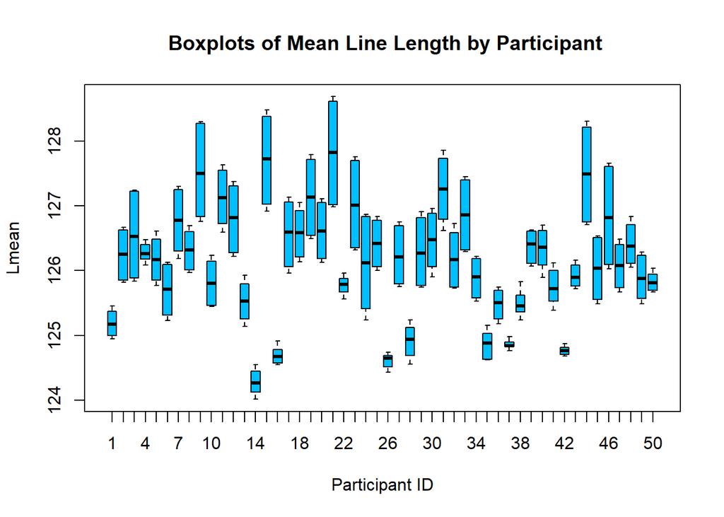

```r
genBP <- plot(tutData$part_ID, tutData$Lmean, xlab = "Participant ID", ylab = "Lmean", pch = 20, col = "deepskyblue",
     main = " Boxplots of Mean Line Length by Participant") #quick visualization of participant boxplots for Lmeans
```

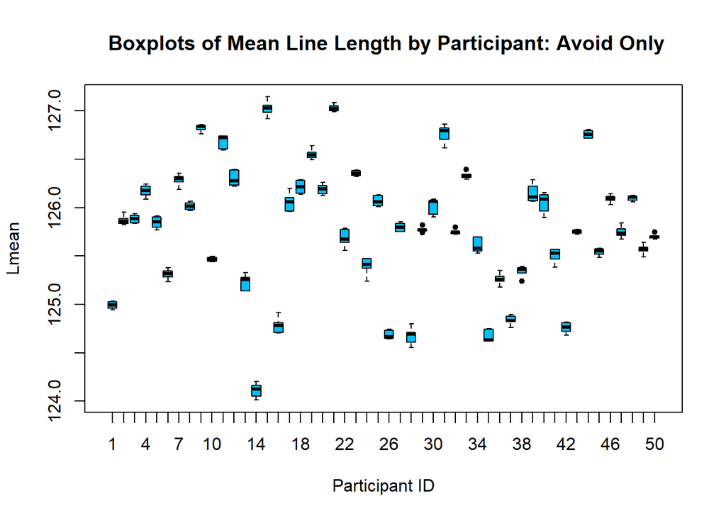

```r
tutData_1 <- filter(tutData, movePhase == 1) #filtering out only avoid condition trials to generate separate plot
genBP_1 <- plot(tutData_1$part_ID, tutData_1$Lmean, xlab = "Participant ID", ylab = "Lmean", pch = 20, col = "deepskyblue",
     main = " Boxplots of Mean Line Length by Participant: Avoid Only") #quick visualization of participant boxplots for Avoid condition Lmeans
```

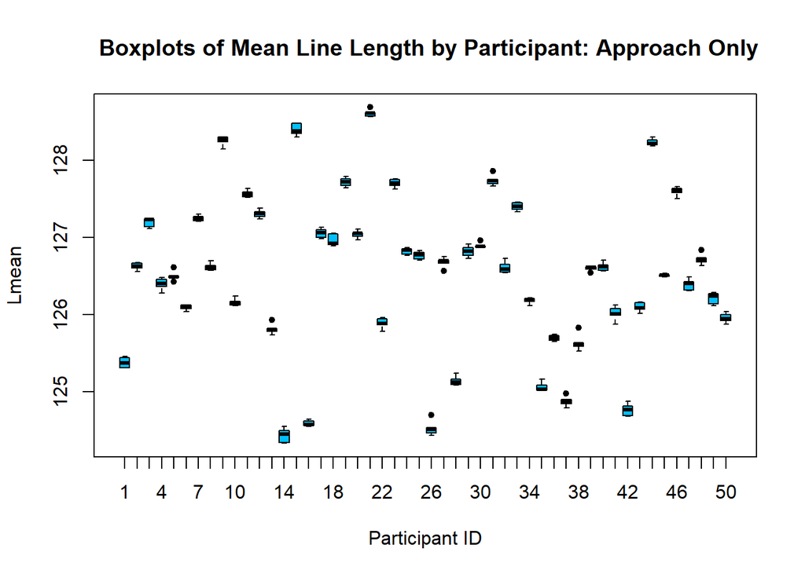

```r
tutData_2 <- filter(tutData, movePhase == 2) #filtering out only approach condition trials to generate separate plot
genBP_2 <- plot(tutData_2$part_ID, tutData_2$Lmean, xlab = "Participant ID", ylab = "Lmean", pch = 20, col = "deepskyblue",
     main = " Boxplots of Mean Line Length by Participant: Approach Only") #quick visualization of participant boxplots for Approach condition Lmeans
```

Now, we need to build our models:

- **Base** (random intercept-only): `Lmean ~ (1|part_ID)`
- **Primary** (fixed + random ints effects added): `Lmean ~ movePhase + (1|part_ID)`
- **Random Effects** (fixed + random ints/slopes): `Lmean ~ movePhase + (movePhase|part_ID)`

In the context of this dataset:

- **Varying intercepts**, if significant, indicate that the *intercept* value (unstandardized beta), which represents the predicted value of *L<sub>mean</sub>* for all participants’ trials before taking into account the condition information (or the grand mean), varies randomly with respect to the participant, with some participants having higher or lower values thereof. As a result, the model is improved (better predictive precision) by allowing the intercepts to be randomly distributed with respect to *part_ID*.
- **Varying slopes**, if significant, indicate that the *slope* value (unstandardized beta), which represents the strength of the relationship between the *movePhase* condition and resulting value of *L<sub>mean</sub>*, is moderated with respect to *part_ID*.

# 3 Building the Multi-level Models

## 3.1 Create models for model-based assumptions tests

```r
base_model <- lmer(Lmean ~ (1|part_ID), tutData %>% arrange(part_ID)) #random intercepts only added to see if model needs them
primary_model <- lmer(Lmean ~ movePhase + (1|part_ID),data=tutData) #let's add the movePhase fixed effect
random_effects_model <- lmer(Lmean ~ movePhase + (movePhase|part_ID), data = tutData) #finally adding the random slope effect
```

We will evaluate the significance of each of these later, but for now, let’s check some assumptions:

## 3.2 Assumptions Tests

### 3.2.1 For the overall residuals, intercepts, and slopes

#### 3.2.1.1 Normality of residuals, random intercepts, and random slopes for model

```r
describe(tutData$resids) #overall residuals; skew and kurtosis look good here
```

```
##    vars   n mean   sd median trimmed  mad   min  max range skew kurtosis se
## X1    1 600    0 0.06      0       0 0.06 -0.16 0.21  0.37 0.17        0  0
```

```r
#first the intercepts:
describe(tutData$per_part_int) #skew and kurtosos look good here
```

```
##    vars   n mean   sd median trimmed  mad   min  max range  skew kurtosis   se
## X1    1 600 0.06 0.45   0.07    0.09 0.45 -1.21 0.87  2.09 -0.66      0.4 0.02
```

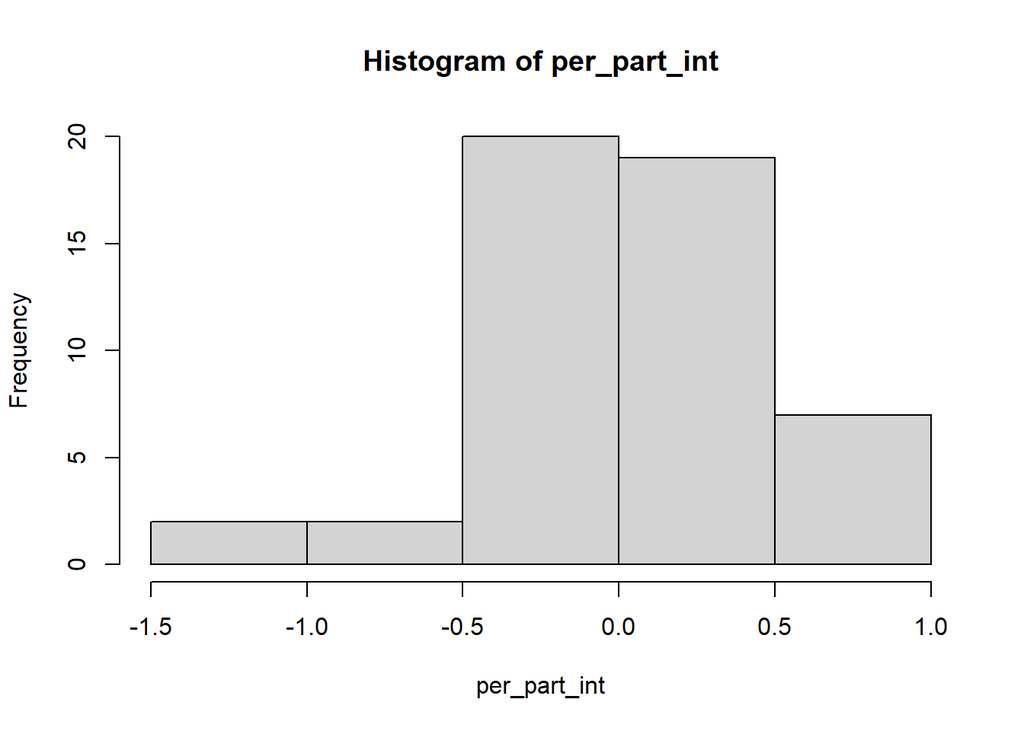

```r
hist(per_part_int) #skew acceptable according to total n size
```

```r
#then the slopes
describe(tutData$per_part_slope) #skew and kurtosis look good here, too
```

```
##    vars   n mean   sd median trimmed  mad   min  max range  skew kurtosis   se
## X1    1 600 0.03 0.43  -0.01    0.03 0.44 -0.95 0.81  1.76 -0.05    -0.41 0.02
```

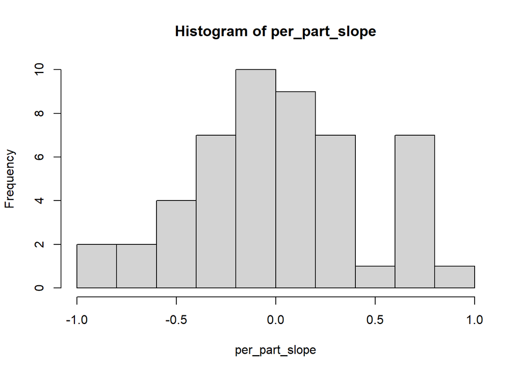

```r
hist(per_part_slope) #kurtosis acceptable according to total n size
```

Everything above looks good (acceptable skew/kurtosis/distribution of residuals, random intercepts, and random slopes), so let’s move on to the models!

### 3.2.2 First, let’s examine the base model

#### 3.2.2.1 Normality of errors for model

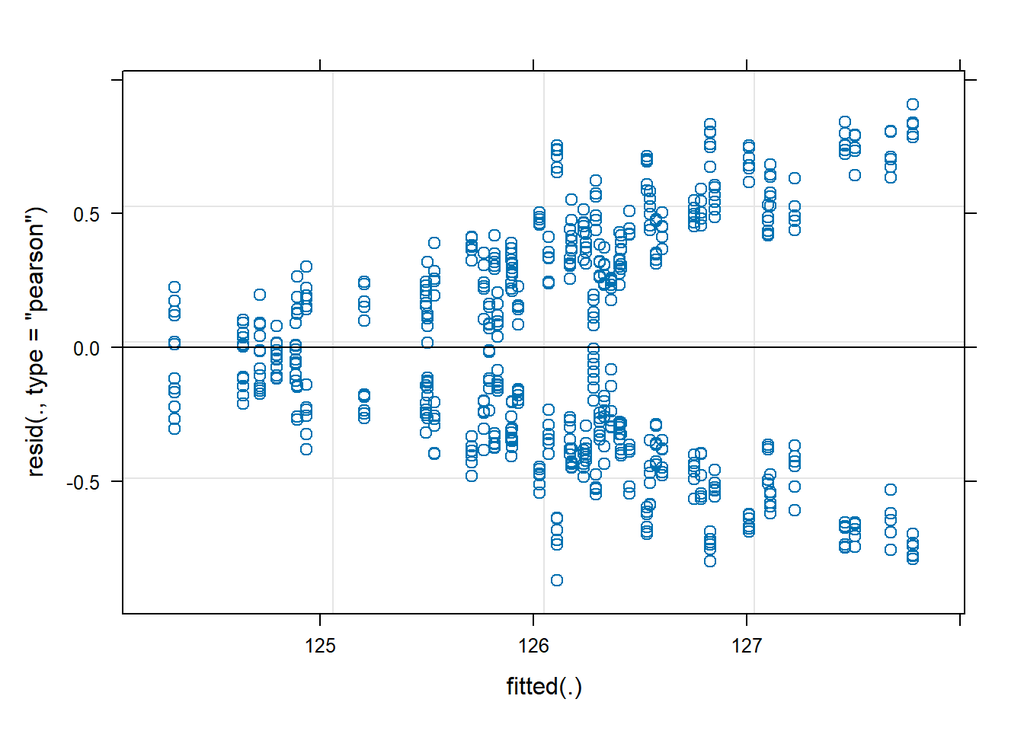

```r
plot(base_model) #residuals vs. fitted plot looks concerning
```

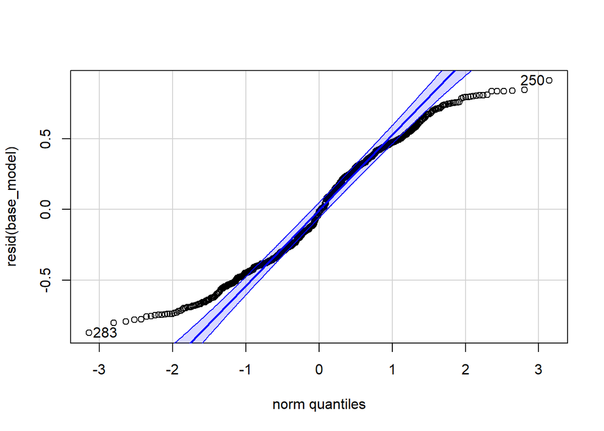

```
## [1] 250 283
```

```r
car::qqPlot(resid(base_model)) #qq plot could be better fit, too
```

- The residuals vs. fitteds plot indicates a **fanning** effect (residuals systematically diverge from zero as *L<sub>mean</sub>* values increase) indicating a clear violation of *homoscedasticity* (see documentation for further explanation).
- The QQ plot indicates that data is insufficiently fitted with respect to a model of only the random intercepts, as indicated by the *non-normal*, s-shaped distribution of the model’s plotted values. More specification seems necessary, so we’ll see what the subsequent models offer.

### 3.2.3 Now, let’s examine the primary model

#### 3.2.3.1 Normality of errors for model

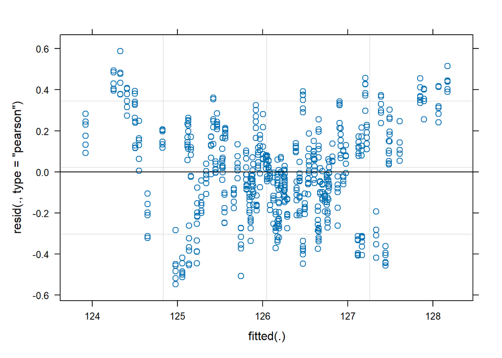

```r
plot(primary_model) # this residuals vs. fitted plot looks less concerning, but there's still room for improvement
```

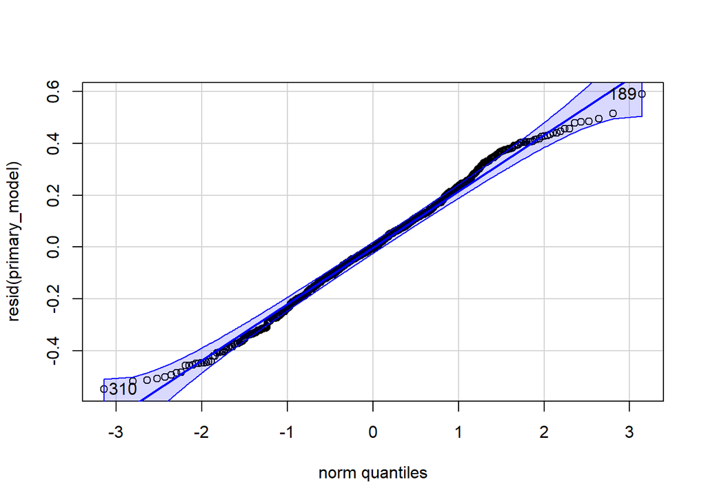

```
## [1] 189 310
```

```r
car::qqPlot(resid(primary_model)) #qq plot could still be improved
```

- Here, the residuals vs. fitteds plot looks *somewhat* better but we do still see a spreading of the error variance at the extremes of the data. The addition of the *movePhase* fixed effect seems to improve the model, but not completely.
- The QQ plot has also improved, but we do still see some deviation from normal for extreme values. More specification might offer further benefits, so let’s look at the random intercepts + slopes model.

### 3.2.4 Finally, let’s examine the random effect (ints + slopes) model’s assumptions

#### 3.2.4.1 Normality of errors for model

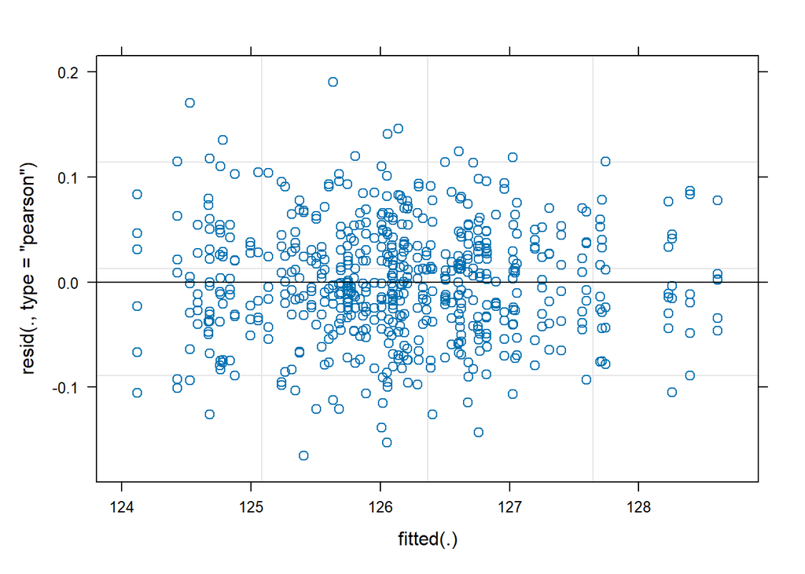

```r
plot(random_effects_model) # these residuals look the best in terms of equal variance around zero
```

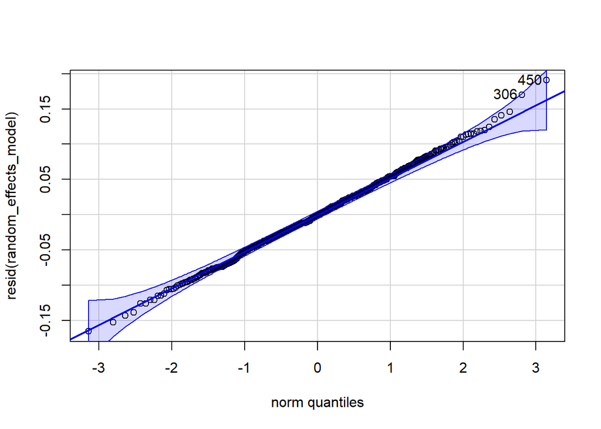

```
## [1] 450 306
```

```r
car::qqPlot(resid(random_effects_model)) #this QQ plot looks good
```

- The residuals vs. fitteds plot shows marked improvement, with most of the residuals being evenly and randomly distributed around zero (note the general coherence to a horizontal band around the 0 line). It looks like including the random effects further improves the initial (base_model’s) violations of *homoscedasticity*.
- The QQ plot also shows further improvements, with most points fitting along the line of normality (or within the 95% confidence interval).
- We can see the gradual improvements that seem to be afforded once we further specify the model, but are these additional models *actually* *statistically* *significant*? And which model is the *ideal*?

## 3.3 Testing the MLMs

### 3.3.1 The Base Model (random intercepts only)

```r
summary(base_model) #significance of model
```

```
## Linear mixed model fit by REML. t-tests use Satterthwaite's method [
## lmerModLmerTest]
## Formula: Lmean ~ (1 | part_ID)
##    Data: tutData %>% arrange(part_ID)
##
## REML criterion at convergence: 925.1
##
## Scaled residuals:
##      Min       1Q   Median       3Q      Max
## -1.94882 -0.81406 -0.03525  0.79560  2.03293
##
## Random effects:
##  Groups   Name        Variance Std.Dev.
##  part_ID  (Intercept) 0.6737   0.8208
##  Residual             0.2001   0.4474
## Number of obs: 600, groups:  part_ID, 50
##
## Fixed effects:
##             Estimate Std. Error       df t value Pr(>|t|)
## (Intercept) 126.1568     0.1175  49.0000    1074   <2e-16 ***
## ---
## Signif. codes:  0 '***' 0.001 '**' 0.01 '*' 0.05 '.' 0.1 ' ' 1
```

```r
ranova(base_model) #significance of random effects
```

```
## ANOVA-like table for random-effects: Single term deletions
##
## Model:
## Lmean ~ (1 | part_ID)
##               npar  logLik     AIC   LRT Df Pr(>Chisq)
## <none>           3 -462.54  931.08
## (1 | part_ID)    2 -808.49 1620.98 691.9  1  < 2.2e-16 ***
## ---
## Signif. codes:  0 '***' 0.001 '**' 0.01 '*' 0.05 '.' 0.1 ' ' 1
```

```r
confint(base_model) #Estimate lower and upper confidence intervals
```

```
## Computing profile confidence intervals ...
```

```
##                   2.5 %      97.5 %
## .sig01        0.6720172   1.0061965
## .sigma        0.4221781   0.4751657
## (Intercept) 125.9243285 126.3892233
```

- Regarding the **Base** model, in which *L<sub>mean</sub>* is predicted by only the random intercepts, we see a significant *part_ID* random effect, *AIC* = 1,620.98, *p* < .001.
- **Varying intercepts** indicate that the *intercept* value for participants’ trials before taking into account the condition information varies randomly with respect to the participant, with some participants having higher or lower values thereof. As a result, the model is improved (better predictive precision) by allowing the intercepts to be randomly distributed with respect to *part_ID*.
- Still, for the reasons addressed during assumptions, and to investigate the fixed effect of *movePhase*, we will continue.

### 3.3.2 The Primary Model (fixed condition effect + random intercepts)

```r
summary(primary_model) #significance of model
```

```
## Linear mixed model fit by REML. t-tests use Satterthwaite's method [
## lmerModLmerTest]
## Formula: Lmean ~ movePhase + (1 | part_ID)
##    Data: tutData
##
## REML criterion at convergence: 218.1
##
## Scaled residuals:
##      Min       1Q   Median       3Q      Max
## -2.33743 -0.63490 -0.01828  0.61464  2.51318
##
## Random effects:
##  Groups   Name        Variance Std.Dev.
##  part_ID  (Intercept) 0.68584  0.8282
##  Residual             0.05484  0.2342
## Number of obs: 600, groups:  part_ID, 50
##
## Fixed effects:
##              Estimate Std. Error        df t value Pr(>|t|)
## (Intercept) 125.06153    0.12096  54.99426 1033.93   <2e-16 ***
## movePhase     0.73016    0.01912 549.00000   38.19   <2e-16 ***
## ---
## Signif. codes:  0 '***' 0.001 '**' 0.01 '*' 0.05 '.' 0.1 ' ' 1
##
## Correlation of Fixed Effects:
##           (Intr)
## movePhase -0.237
```

```r
ranova(primary_model) #significance of random effects
```

```
## ANOVA-like table for random-effects: Single term deletions
##
## Model:
## Lmean ~ movePhase + (1 | part_ID)
##               npar  logLik    AIC    LRT Df Pr(>Chisq)
## <none>           4 -109.05  226.1
## (1 | part_ID)    3 -759.80 1525.6 1301.5  1  < 2.2e-16 ***
## ---
## Signif. codes:  0 '***' 0.001 '**' 0.01 '*' 0.05 '.' 0.1 ' ' 1
```

```r
confint(primary_model) #Estimate lower and upper confidence intervals
```

```
## Computing profile confidence intervals ...
```

```
##                   2.5 %      97.5 %
## .sig01        0.6809825   1.0121977
## .sigma        0.2207850   0.2484957
## (Intercept) 124.8226287 125.3004329
## movePhase     0.6926575   0.7676693
```

```r
describeBy(tutData$Lmean, group = tutData$movePhase) #looking at the data descriptives by condition of movePhase
```

```
##
##  Descriptive statistics by group
## group: 1
##    vars   n   mean   sd median trimmed  mad    min    max range skew kurtosis
## X1    1 300 125.79 0.66 125.83  125.81 0.59 124.01 127.14  3.13 -0.3    -0.23
##      se
## X1 0.04
## ------------------------------------------------------------
## group: 2
##    vars   n   mean   sd median trimmed  mad    min    max range  skew kurtosis
## X1    1 300 126.52 1.01  126.6  126.54 0.94 124.33 128.69  4.36 -0.16    -0.37
##      se
## X1 0.06
```

- Regarding the **Primary** model, in which *L<sub>mean</sub>* is predicted by a fixed effect of *movePhase* and a random intercepts effect, there was a significant effect of *movePhase*, *b* = 0.73 (*SE* = .02), *t*(549) = 38.19, *p* < .001. This indicates that, for those in the Avoid condition, *L<sub>mean</sub>* values were significantly lower than those in the Approach condition.

### 3.3.3 The Random Effects Model (fixed condition effect + random intercepts and slopes)

```r
summary(random_effects_model) #significance of model
```

```
## Linear mixed model fit by REML. t-tests use Satterthwaite's method [
## lmerModLmerTest]
## Formula: Lmean ~ movePhase + (movePhase | part_ID)
##    Data: tutData
##
## REML criterion at convergence: -1099.1
##
## Scaled residuals:
##     Min      1Q  Median      3Q     Max
## -2.7971 -0.5997 -0.0192  0.5845  3.2222
##
## Random effects:
##  Groups   Name        Variance Std.Dev. Corr
##  part_ID  (Intercept) 0.211061 0.4594
##           movePhase   0.191712 0.4378   0.08
##  Residual             0.003505 0.0592
## Number of obs: 600, groups:  part_ID, 50
##
## Fixed effects:
##              Estimate Std. Error        df t value Pr(>|t|)
## (Intercept) 125.06153    0.06542  49.00032 1911.70  < 2e-16 ***
## movePhase     0.73016    0.06211  48.99763   11.76 7.18e-16 ***
## ---
## Signif. codes:  0 '***' 0.001 '**' 0.01 '*' 0.05 '.' 0.1 ' ' 1
##
## Correlation of Fixed Effects:
##           (Intr)
## movePhase 0.070
```

```r
ranova(random_effects_model) #significance of random effects
```

```
## ANOVA-like table for random-effects: Single term deletions
##
## Model:
## Lmean ~ movePhase + (movePhase | part_ID)
##                                    npar  logLik     AIC    LRT Df Pr(>Chisq)
## <none>                                6  549.57 -1087.1
## movePhase in (movePhase | part_ID)    4 -109.05   226.1 1317.2  2  < 2.2e-16
##
## <none>
## movePhase in (movePhase | part_ID) ***
## ---
## Signif. codes:  0 '***' 0.001 '**' 0.01 '*' 0.05 '.' 0.1 ' ' 1
```

```r
confint(random_effects_model) #Estimate lower and upper confidence intervals
```

```
## Computing profile confidence intervals ...
```

```
##                    2.5 %       97.5 %
## .sig01        0.37712270   0.56217178
## .sig02        0.36007945   0.53509359
## .sig03       -0.19977684   0.34644814
## .sigma        0.05571603   0.06307218
## (Intercept) 124.93212299 125.19093856
## movePhase     0.60730414   0.85302268
```

- Regarding the **Random effects** model, in which *L<sub>mean</sub>* is predicted by a fixed effect of *movePhase* and random slope and intercept effects of *part_ID*, there was a significant effect of adding the random *part_ID* slope effect on *movePhase* (in addition to the random *part_ID* intercept), *AIC* = 226.10, *p* < .001.
- Further, **varying slopes** indicate that the fixed effect of *movePhase* is moderated with respect to *part_ID*, with the condition having stronger effects on *L<sub>mean</sub>* values for some, and weaker effects for others. This is in addition to the *part_ID* random intercept effect.

### 3.3.4 The FINAL Model Check: Atheoretical Stepwise Analysis

```r
full_model <- random_effects_model #assign model with all effects of interest (random and fixed) to see what Stepwise deems necessary
step_model <- lmerTest::step(full_model)#stepwise function takes the full model and decides which effects to keep and drop to best account for model variance
final_model <- step_model %>% get_model() #which is the best?
summary(final_model) #looks like the slopes model wins!
```

```
## Linear mixed model fit by REML. t-tests use Satterthwaite's method [
## lmerModLmerTest]
## Formula: Lmean ~ movePhase + (movePhase | part_ID)
##    Data: tutData
##
## REML criterion at convergence: -1099.1
##
## Scaled residuals:
##     Min      1Q  Median      3Q     Max
## -2.7971 -0.5997 -0.0192  0.5845  3.2222
##
## Random effects:
##  Groups   Name        Variance Std.Dev. Corr
##  part_ID  (Intercept) 0.211061 0.4594
##           movePhase   0.191712 0.4378   0.08
##  Residual             0.003505 0.0592
## Number of obs: 600, groups:  part_ID, 50
##
## Fixed effects:
##              Estimate Std. Error        df t value Pr(>|t|)
## (Intercept) 125.06153    0.06542  49.00032 1911.70  < 2e-16 ***
## movePhase     0.73016    0.06211  48.99763   11.76 7.18e-16 ***
## ---
## Signif. codes:  0 '***' 0.001 '**' 0.01 '*' 0.05 '.' 0.1 ' ' 1
##
## Correlation of Fixed Effects:
##           (Intr)
## movePhase 0.070
```

Since stepwise regression analyses can be used to atheoretically fit an optimal model to a dataset, I decided to load in the slopes model (which contains all fixed and random effects of interest) into the step model test; results correspond with those of the MLM analysis, with the most optimal model being that of the slopes model, **Random Effects** (fixed + random ints/slopes): `Lmean ~ movePhase + (movePhase|part_ID)`.

That’s all folks! :)